## Fit Data Summary - Assignment for Reproducible Research, Week 2

### Preliminary step: Read in the data and load key libraries.

```r
FitData <- read.csv("activity.csv", header=TRUE)
library(dplyr)
```

```r
library(ggplot2)
library(xtable)
library(knitr)
library(markdown)
```

### QUESTION 1 - What is the mean total number of steps taken per day?

#### PART 1 - Calculate totals by date, and the mean of those totals, excluding nas. Show result.

```r
SumStepsByDate <- FitData %>% group_by(date) %>% summarize (sum.steps = sum(steps, na.rm=TRUE))
MeanStepsByDate <- mean(SumStepsByDate$sum.steps)
MeanStepsByDate
```

```
## [1] 9354.23
```

The mean number of steps taken per day is: 9354.2295082

#### PART 2 - Create a histogram of the total steps taken per day.

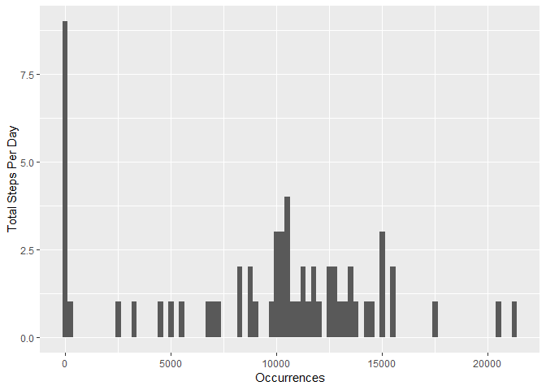

```r
qplot(sum.steps, data=SumStepsByDate, binwidth=250,
      xlab = "Occurrences", ylab = "Total Steps Per Day")
```

#### PART 3 - Calculate and report mean and median of total number of steps taken per day.

```r
StepsMean <- mean(SumStepsByDate$sum.steps)
StepsMedian <- median(SumStepsByDate$sum.steps)
StepsMean
```

```
## [1] 9354.23
```

```r
StepsMedian
```

```
## [1] 10395
```

The mean total steps taken per day is 9354.2295082; the median is 10395.

### QUESTION 2 - What is the average daily activity pattern?

#### PART 1 - Make a time series plot of the average steps taken by 5-minute interval.

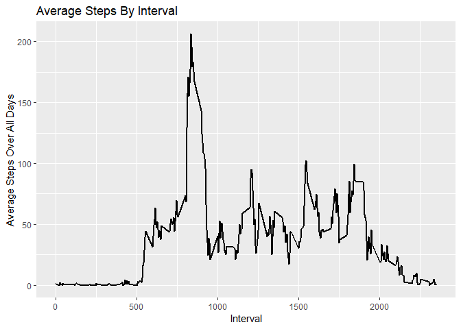

```r
StepsByInterval <- group_by(FitData, interval)
AvgStepsByInterval <- summarize(StepsByInterval, avg.steps = mean(steps, na.rm=TRUE))
Plot <- ggplot (AvgStepsByInterval, aes(interval, avg.steps))
Plot + geom_line(size = 1, linetype = 1) + labs(title = "Average Steps By Interval") + labs(x = "Interval", y = "Average Steps Over All Days")
```

#### PART 2 - Find the interval with the maximum average steps over all days.

```r
MaxAvg <- AvgStepsByInterval[which.max(AvgStepsByInterval$avg.steps),]
MaxAvg
```

```
## # A tibble: 1 x 2
##   interval avg.steps
##      <int>     <dbl>
## 1      835      206.
```

The time interval with the highest average steps across all days is interval 835 with 206 steps.

### QUESTION 3 - Imputing Missing Values

#### PART 1 - Calculate and report the total number of missing values in the dataset.

```r
CountNA <- sum(is.na(FitData$steps))
CountNA
```

```
## [1] 2304
```

```r
meanNA <- mean(is.na(FitData$steps))
```

#### PART 2 - Devise a strategy for filling in the missing data.

The strategy is to replace each NA with the average of that interval over all days.

#### PART 3 - Create a new dataset with the missing values filled in.

```r
## create a column with average steps
FitDataPlus <- cbind (FitData, AvgStepsByInterval)
colnames(FitDataPlus) <- c("steps", "date", "interval", "interval2", "avg.steps")
## remove the extra intervals column
FitDataPlus$interval2 <- NULL
## add the imputed values
ind <- is.na(FitDataPlus$steps)
FitDataPlus$steps[ind] <- FitDataPlus$avg.steps[ind]
NewSumStepsByDate <- FitDataPlus %>% group_by(date) %>%
      summarize (sum.steps = sum(steps))
```

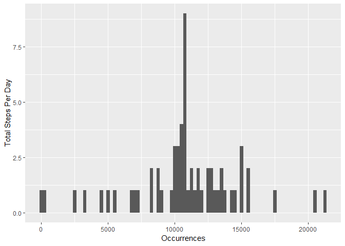

```r
qplot(sum.steps, data=NewSumStepsByDate, binwidth=250,
      xlab = "Occurrences", ylab = "Total Steps Per Day")
```

```r
NewStepsMean <- mean(NewSumStepsByDate$sum.steps)
NewStepsMedian <- median(NewSumStepsByDate$sum.steps)
```

### QUESTION 4 - Investigating weekday vs. weekend activity

#### PART 1 - Create a new factor variable indicating weekend or weekday.

```r
FitDataPlus$day <- weekdays(as.Date(FitDataPlus$date))
FitDataPlus$weekend <- if_else(FitDataPlus$day %in% c("Saturday", "Sunday"), "Weekend", "Weekday")
```

#### PART 2 - Make a panel plot of interval vs. average steps - weekend vs. weekday.

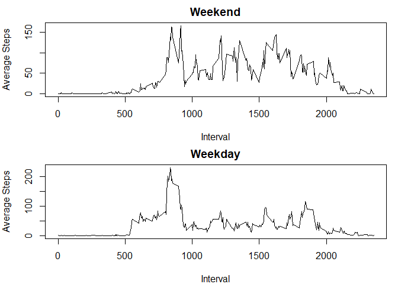

```r
## establish which days are weekdays and which are weekends
FitDataPlus$day <- weekdays(as.Date(FitDataPlus$date))
FitDataPlus$weekend <- if_else(FitDataPlus$day %in% c("Saturday", "Sunday"), "Weekend", "Weekday")
## calculate the average steps per interval for each data set, weekend vs. weekday
DataWeekend <- subset(FitDataPlus, weekend == "Weekend")
DataWeekday <- subset(FitDataPlus, weekend == "Weekday")
AvgStepsWeekend <- DataWeekend %>% group_by(interval) %>%
      summarize (avg.steps = mean(steps))
AvgStepsWeekday <- DataWeekday %>% group_by(interval) %>%
      summarize (avg.steps = mean(steps))
par(mfrow = c(2, 1), mar = c(4,4,2,1))
plot(AvgStepsWeekend$interval, AvgStepsWeekend$avg.steps, type = "l",
     xlab = "Interval", ylab = "Average Steps", main = "Weekend")
plot(AvgStepsWeekday$interval, AvgStepsWeekday$avg.steps, type = "l",
     xlab = "Interval", ylab = "Average Steps", main = "Weekday")
```